# ANOVA R

# Question 3 continued….

Now we can re-run the ANOVA test, do the FDR corrections, and get out results

```r
# This re-runs the ANOVA with our new cutoffs in place.
for(i in 1:nrow(otu.m)){
  y <- as.numeric(otu.m[i,])
  aovOut <- aov(y ~ sex)
  pvals.sex[i] <- summary(aovOut)[[1]][1,5]
}

for(i in 1:nrow(otu.m)){
  y <- as.numeric(otu.m[i,])
  aovOut <- aov(y ~ bs)
  pvals.bs[i] <- summary(aovOut)[[1]][1,5]
}

for(i in 1:nrow(otu.m)){
  y <- as.numeric(otu.m[i,])
  aovOut <- aov(y ~ ba)
  pvals.ba[i] <- summary(aovOut)[[1]][1,5]
}

# Re-do the FDR correction
pvals.sex = p.adjust(pvals.sex, "fdr")
pvals.bs = p.adjust(pvals.bs, "fdr")
pvals.ba = p.adjust(pvals.ba, "fdr")

# Now we can find how many are significant for each variable
sum(pvals.sex < 0.05)
```

```
## [1] 2
```

```r
sum(pvals.bs < 0.05)
```

```
## [1] 143
```

```r
sum(pvals.ba < 0.05)
```

```
## [1] 150
```

# Question 3 continued

To identify at least one that is significantly correlated, we re-plot the signifcant OTUs (p < 0.05) from the ANOVA results. The plot title will tell us which are significant. This will tell us the significant OTUs for the variable “sex”

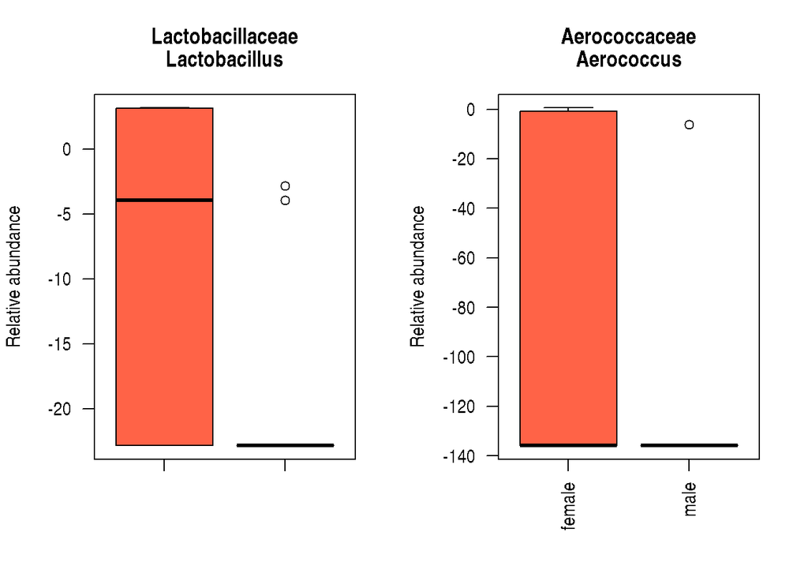

```r
plot.new()
par(mfrow=c(1,2))
for(i in which(pvals.sex < 0.05)){
  y = as.numeric(otu.m[i,])
  name1 = gsub('; .__',' ', as.character(otuNames[i]))
  name2 = gsub('k__','', name1)
  name3 = gsub('  ','', name2)
  name = strsplit(name3, " ", fixed=T)[[1]]
  names_tail = tail(name, n=2)
  boxplot(y ~ sex, main=names_tail, ylab="Relative abundance", col=c("tomato", "gray"), las=2)}
```

# Question 3 continued

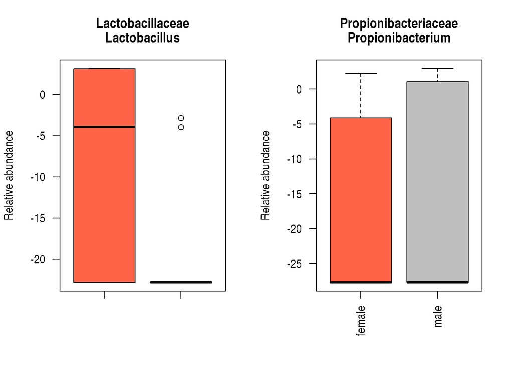

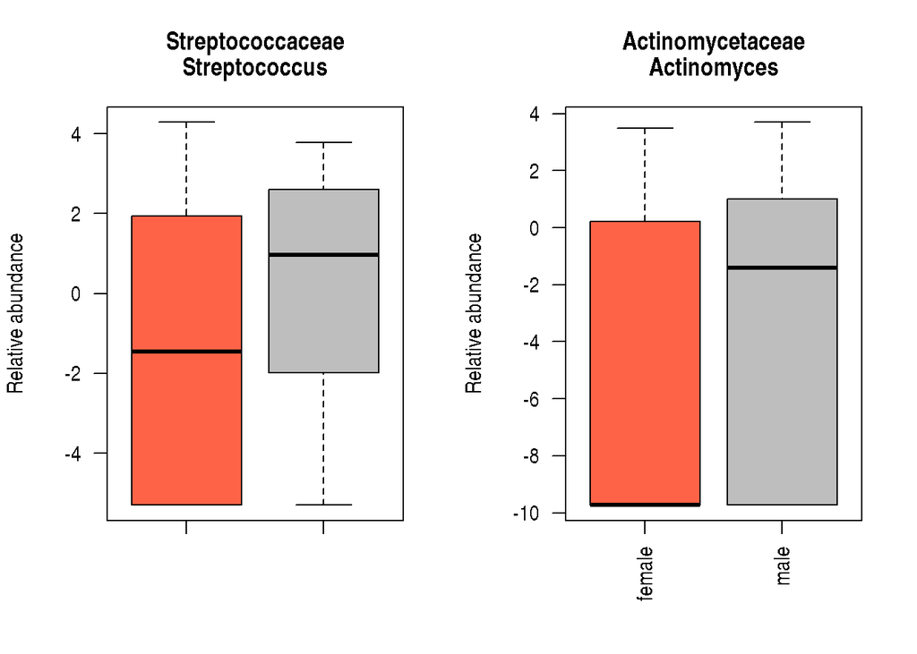

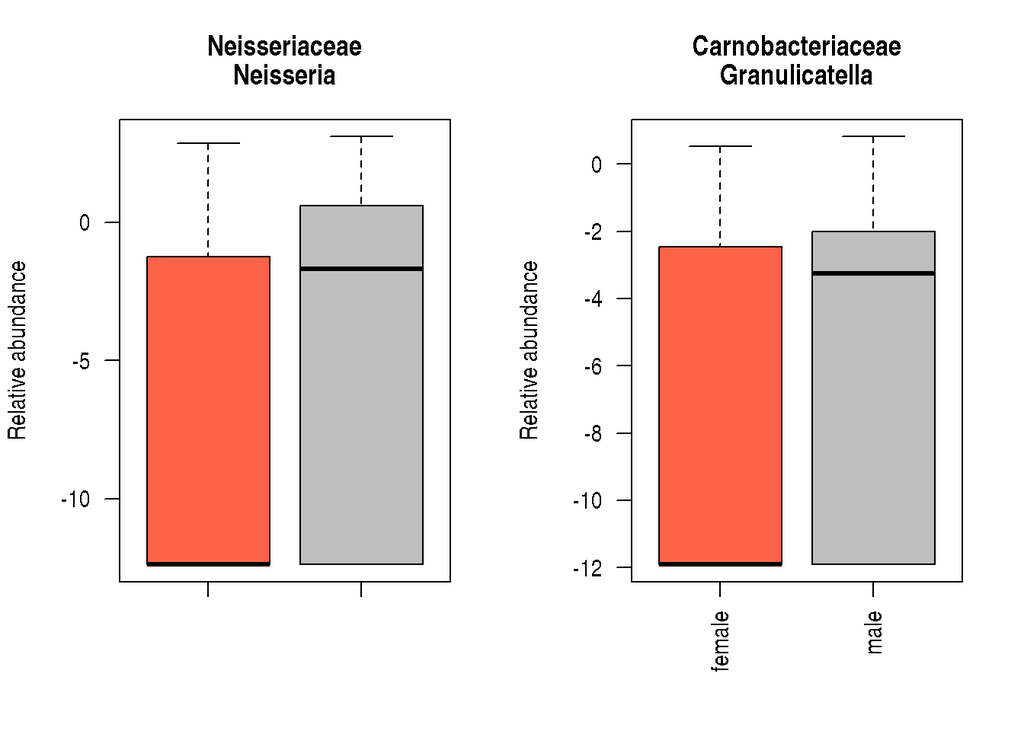

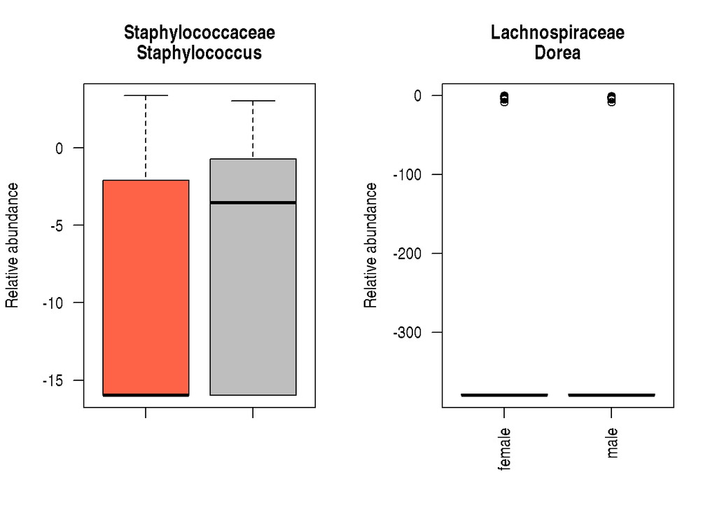

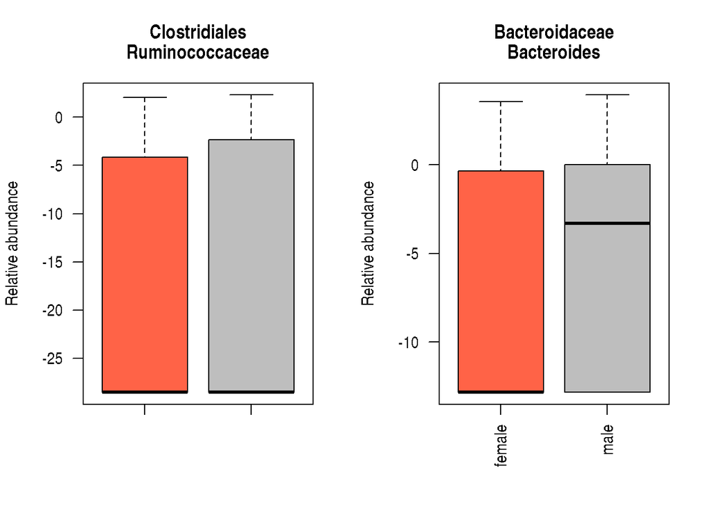

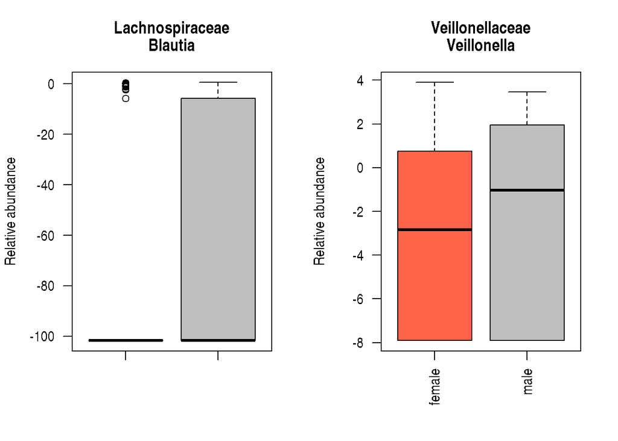

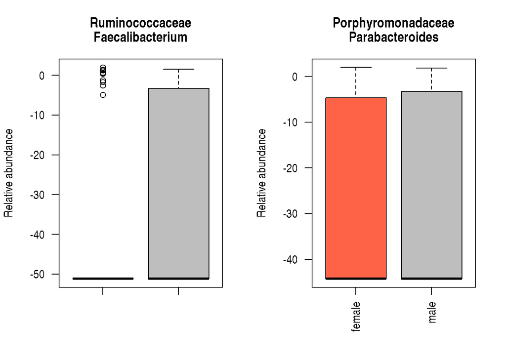

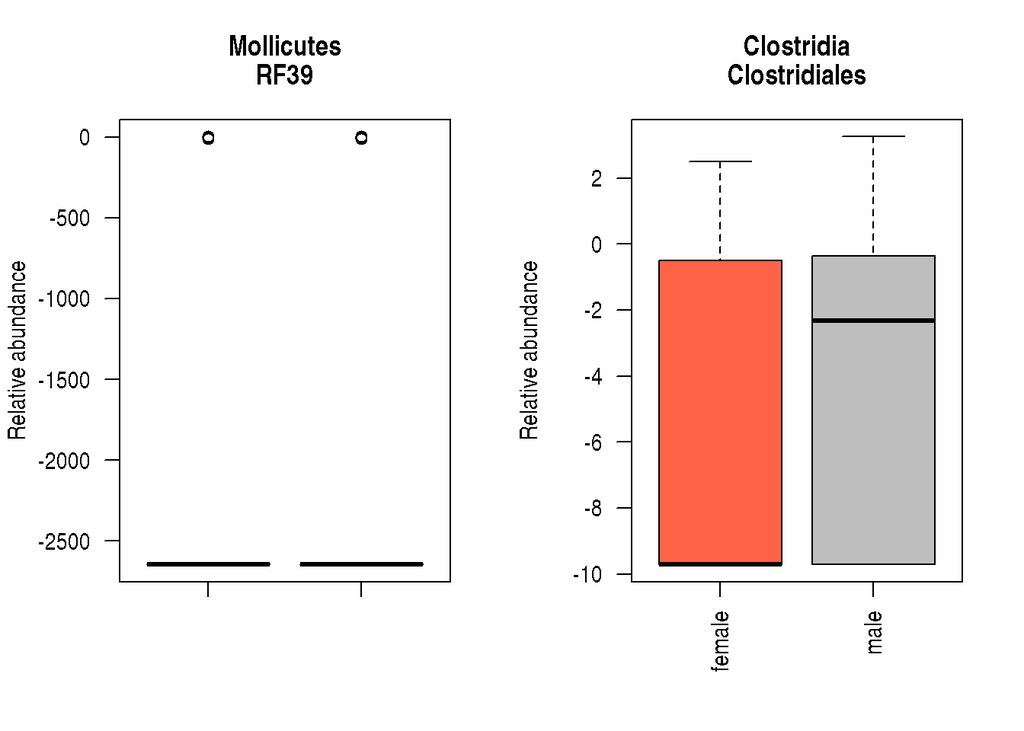

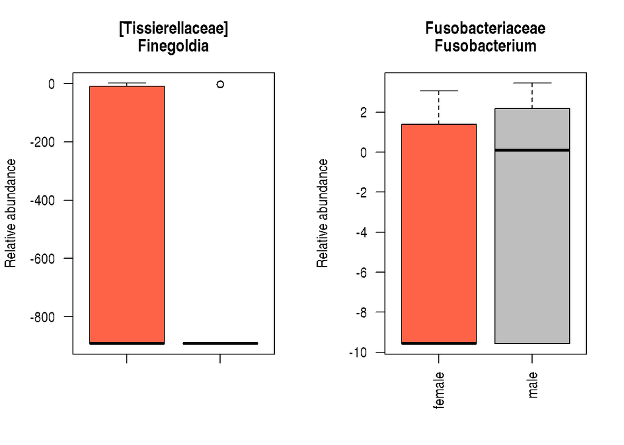

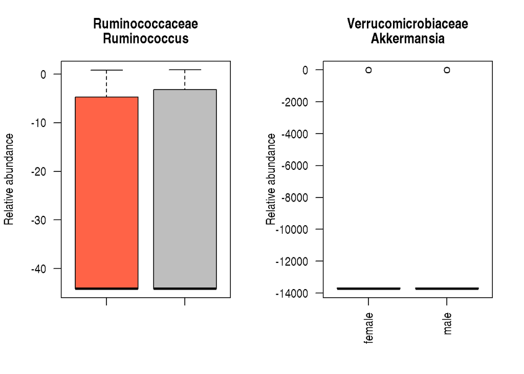

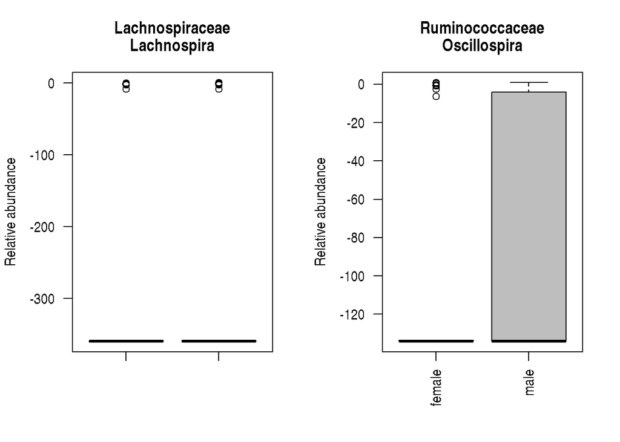

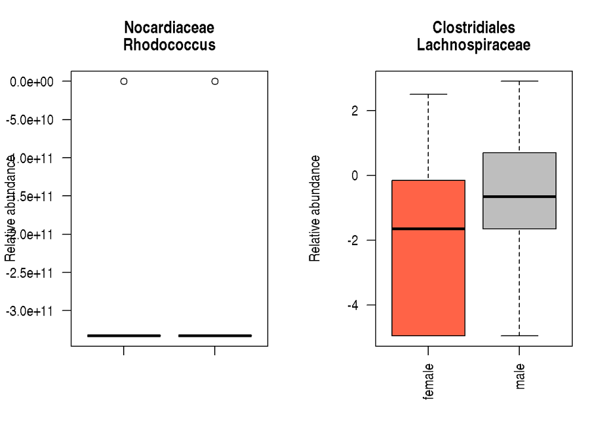

[60 more figures not shown]

```r
plot.new()
par(mfrow=c(1,2))
for(i in which(pvals.bs < 0.05)){
  y = as.numeric(otu.m[i,])
  name1 = gsub('; .__',' ', as.character(otuNames[i]))
  name2 = gsub('k__','', name1)
  name3 = gsub('  ','', name2)
  name = strsplit(name3, " ", fixed=T)[[1]]
  names_tail = tail(name, n=2)
  boxplot(y ~ sex, main=names_tail, ylab="Relative abundance", col=c("tomato", "gray"), las=2)}
```

For question 3b, you will re-run things above but change genus to class

# Question 4

Question 4 is similar to Question 3

# Question 5

For question 5 we would do similar to above, but we can choose a single variable. So we only need to re-use certain parts of the code.

```r
# reload taxa, changing TL for each part of the question
otlOut <- otu_tax_lev('otu_rare2000.txt', TL='genus')

# Assign the otu table to the variable otu.m, and otu names to otuNames
otu.m <- otlOut$otu_table
otuNames <- otlOut$otuNames

# Change to relative abundance
for(i in 1:ncol(otu.m)){
  otu.m[,i] <- 100*otu.m[,i]/sum(otu.m[,i])
}

# Our cutoff is set for taxa that occur in 4 or more individuals
# BUT now we must change the minimum abundance to 0.1, which we can change at the 0 level
#cutoff <- rowSums(otu.m[,1:ncol(otu.m)] > 0) >= 4
cutoff <- rowSums(otu.m[,1:ncol(otu.m)] > 0.1) >= 4

otu.m <- otu.m[cutoff,]
otuNames <- otuNames[cutoff]

for (i in 1:nrow(otu.m)){
  otu.m[i,] = boxCoxNormalize(otu.m[i,])
}

# Let's only do bodyarea here...
pvals.ba <- vector()

for(i in 1:nrow(otu.m)){
  y <- as.numeric(otu.m[i,])
  aovOut <- aov(y ~ ba)
  pvals.ba[i] <- summary(aovOut)[[1]][1,5]
}

# Re-do the FDR correction
pvals.ba = p.adjust(pvals.ba, "fdr")

# Now we can find how many are significant for each variable
sum(pvals.ba < 0.05)
```

```
## [1] 114
```

# Question 6

```
## [1] "Lactobacillaceae" "Lactobacillus"
```

```
## [1] "Propionibacteriaceae" "Propionibacterium"
```

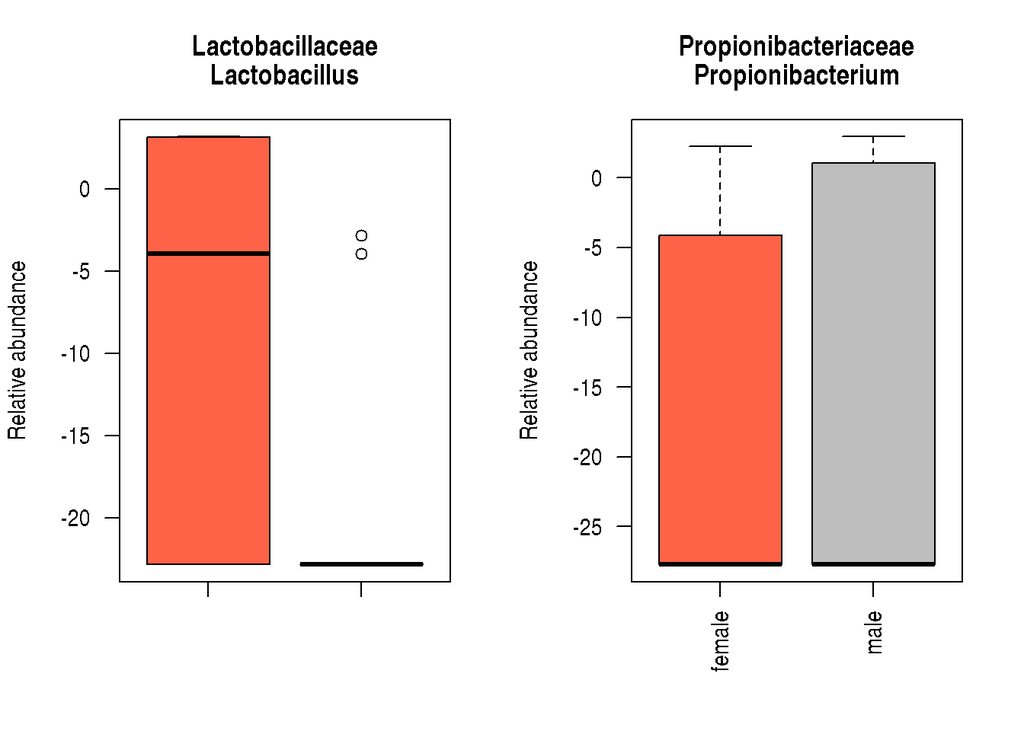

```
## [1] "Streptococcaceae" "Streptococcus"
```

```
## [1] "Actinomycetaceae" "Actinomyces"
```

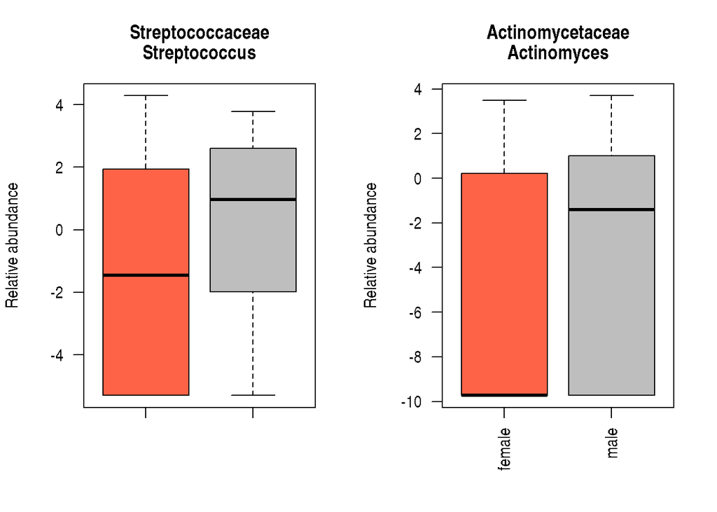

```
## [1] "Neisseriaceae" "Neisseria"
```

```
## [1] "Carnobacteriaceae" "Granulicatella"
```

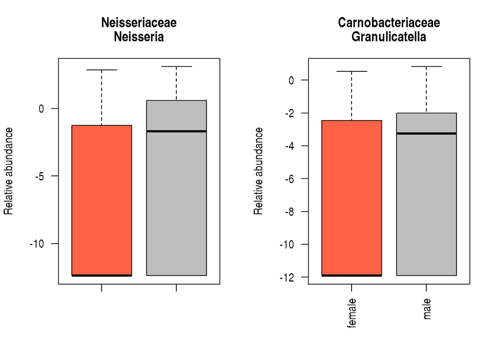

```
## [1] "Staphylococcaceae" "Staphylococcus"
```

```
## [1] "Lachnospiraceae" "Dorea"
```

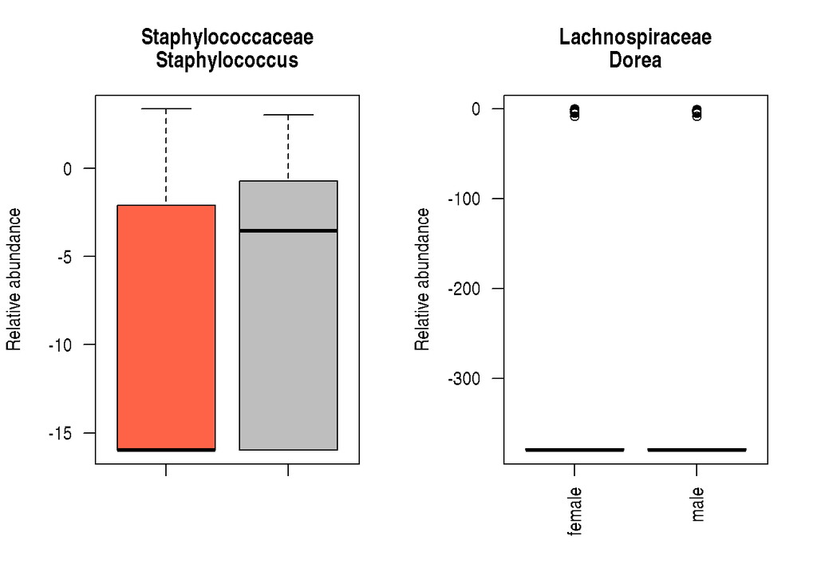

```
## [1] "Clostridiales"   "Ruminococcaceae"
```

```
## [1] "Bacteroidaceae" "Bacteroides"
```

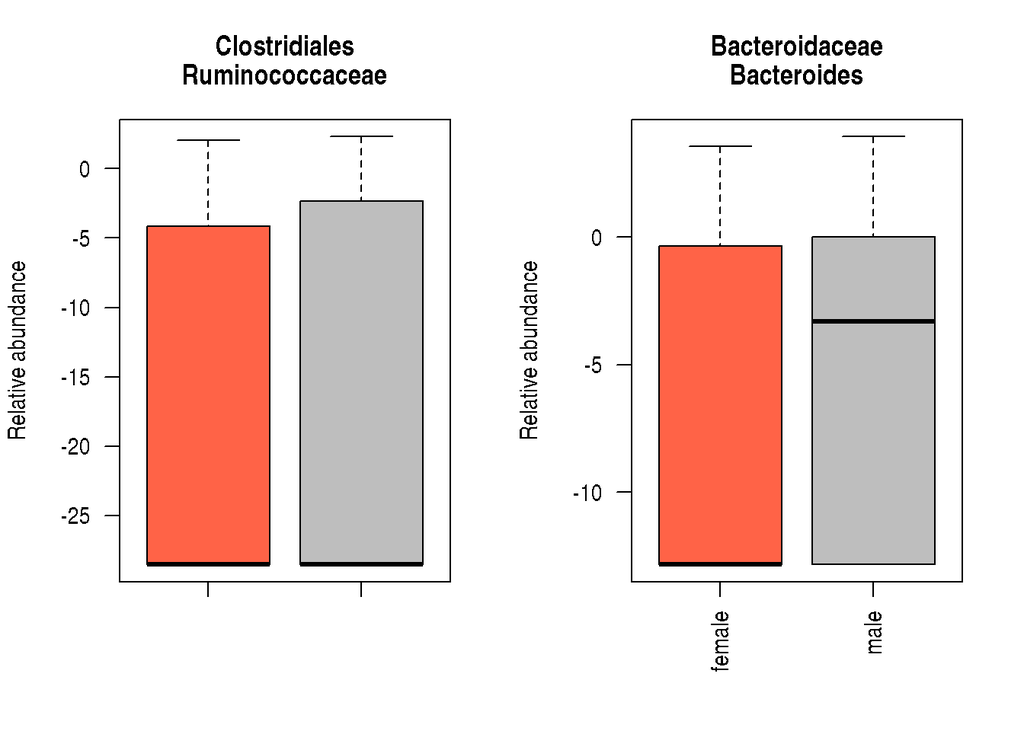

```
## [1] "Lachnospiraceae" "Blautia"
```

```
## [1] "Veillonellaceae" "Veillonella"
```

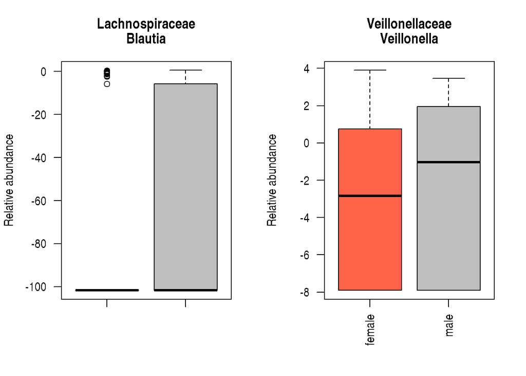

```
## [1] "Ruminococcaceae"  "Faecalibacterium"
```

```
## [1] "Porphyromonadaceae" "Parabacteroides"
```

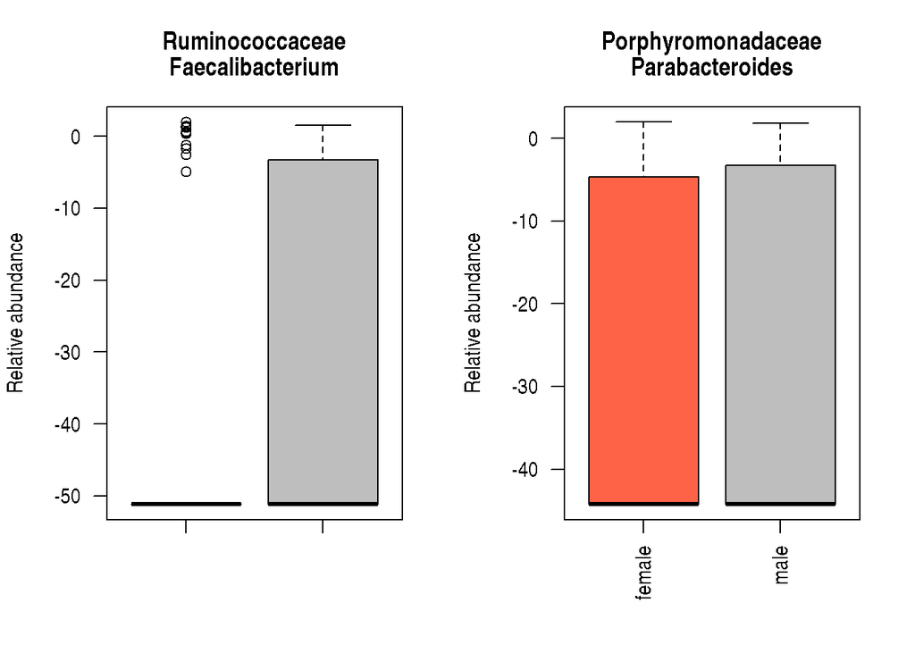

```
## [1] "Mollicutes" "RF39"
```

```
## [1] "Clostridia"    "Clostridiales"
```

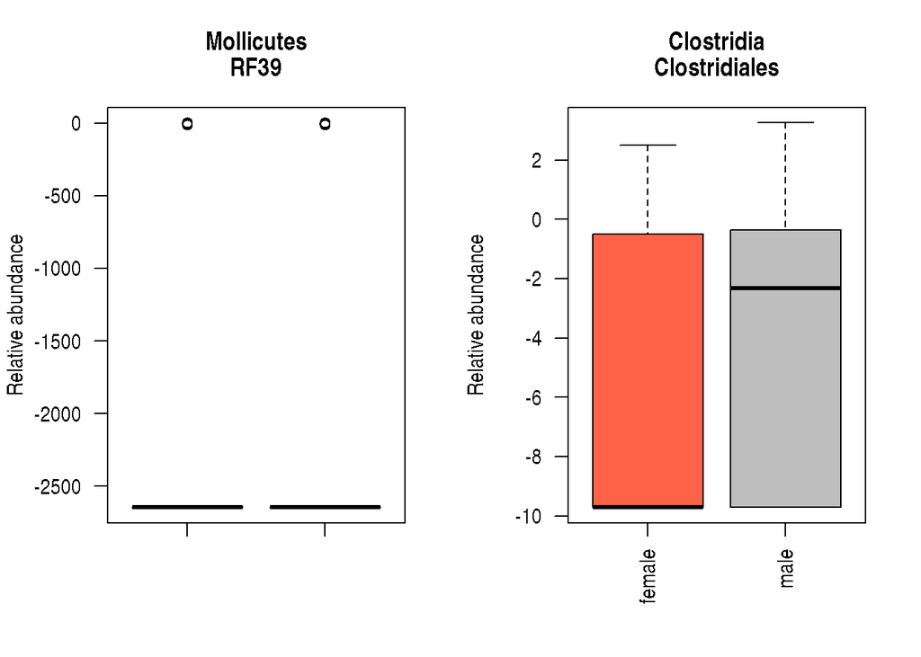

```
## [1] "[Tissierellaceae]" "Finegoldia"
```

```
## [1] "Fusobacteriaceae" "Fusobacterium"
```

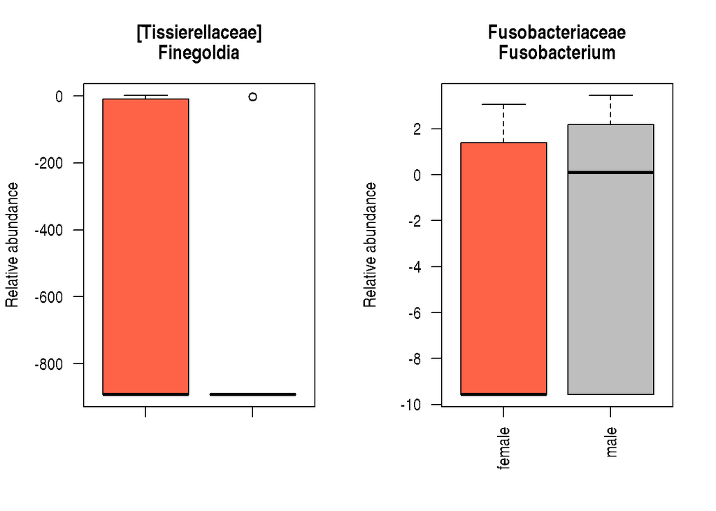

```
## [1] "Ruminococcaceae" "Ruminococcus"
```

```
## [1] "Verrucomicrobiaceae" "Akkermansia"
```

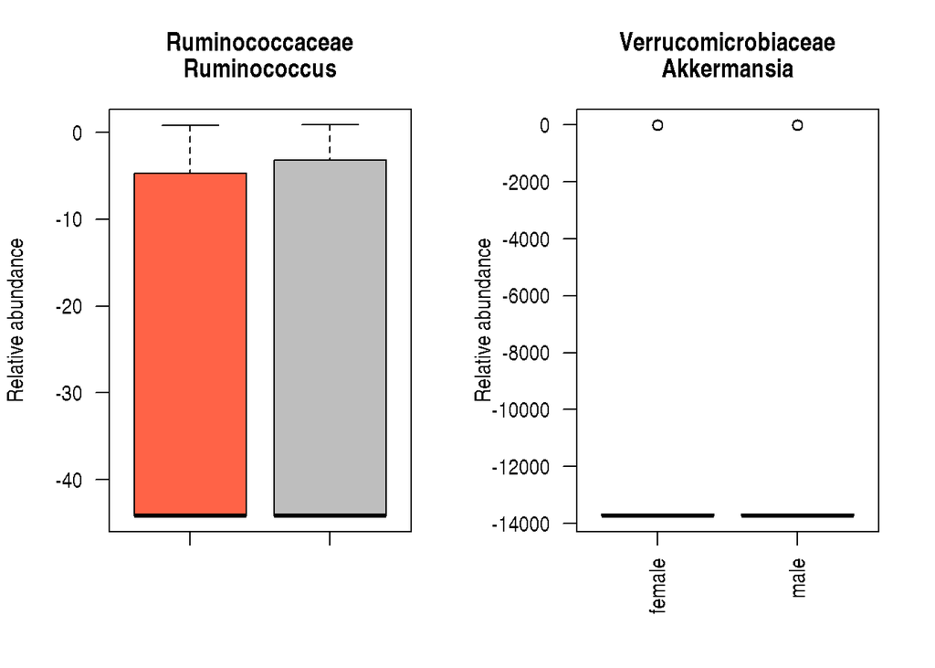

```
## [1] "Lachnospiraceae" "Lachnospira"
```

```
## [1] "Ruminococcaceae" "Oscillospira"
```

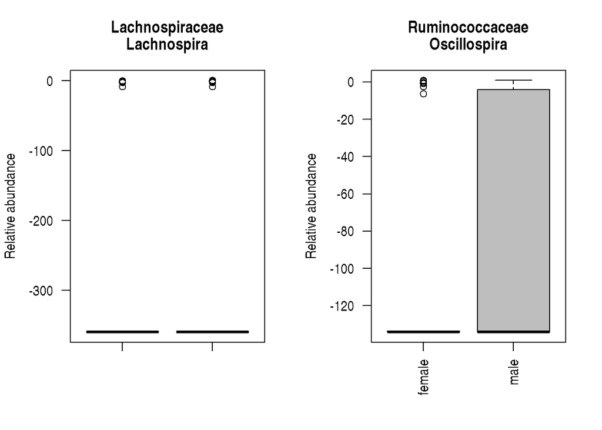

```
## [1] "Clostridiales"   "Lachnospiraceae"
```

```
## [1] "Lachnospiraceae" "Coprococcus"
```

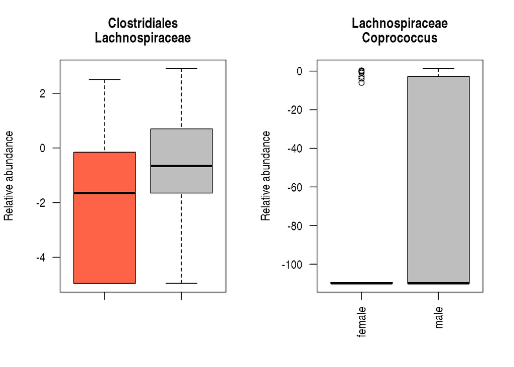

```
## [1] "Gemellales"  "Gemellaceae"
```

```
## [1] "Veillonellaceae" "Selenomonas"
```

[45 more figures not shown]

```r
plot.new()
par(mfrow=c(1,2))
for(i in which(pvals.ba < 0.05)){
  y = as.numeric(otu.m[i,])
  name1 = gsub('; .__',' ', as.character(otuNames[i]))
  name2 = gsub('k__','', name1)
  name3 = gsub('  ','', name2)
  name = strsplit(name3, " ", fixed=T)[[1]]
  names_tail = tail(name, n=2)
  # "Added print line"
  print(names_tail)
  boxplot(y ~ sex, main=names_tail, ylab="Relative abundance", col=c("tomato", "gray"), las=2)
}
```